# Bayesian Models in Psychology

October 10, 2017

## Lab 2

### Binomial Models

## Bayesian updating

Bayes theorem

\(P(B | A) = \frac{P(A | B) \times P(B)}{P(A)}\)

## Bayesian updating

\(P(\theta | \mathcal{D}) = \frac{P(\mathcal{D}|\theta) \times P(\theta)}{P(\mathcal{D})}\)

- \(\mathcal{D}\) - data, i.e. results of an experiment or observation, fixed
- \(\theta\) - parameters responsible for generating data, random

## Example 1

- When tossing a coin we have some beliefs about the frequencies of heads and tails - \(\theta\). If we believe that the coin is fair, we expect that \(P(heads) = P(tails) = 1/2\) . When actually tossing a coin (suppose 10 times) we are obtaining some proportion of heads and tails, say 6 to 4 - \(\mathcal{D}\).

## Example 2

- Before conducting a study on sleeping disorders (SD), we may have some beliefs about the frequency of SD. Say we believe that it is present among 25% percent of undergraduate students - \(\theta\). After conducting the study on N = 100 undergraduates, we observe SD among 40 of undergraduates - \(\mathcal{D}\)

## Example 3

- It is well known that IQ has a mean, \(\mu = 100\) and standard deviation, \(\sigma = 15\) - we can jointly name these two values as \(\theta\). We can expect these values in a random sample. However, after conducting a sample of school students we observe mean, m = 97, and standard deviation, SD = 20 - \(\mathcal{D}\)

## Bayesian updating

\(P(\theta | \mathcal{D}) = \frac{P(\mathcal{D}|\theta) \times P(\theta)}{P(\mathcal{D})}\)

- \(\mathcal{D}\) - data, i.e. results of an experiment or observation, fixed
- \(\theta\) - parameters responsible for generating data, random

## Bayesian updating

\(P(\theta | \mathcal{D}) \propto P(\mathcal{D}|\theta) \times P(\theta)\)

posterior = likelihood \(\times\) prior

Each new observation changes our beliefs about parameters responsible for generating data.

## Prior \(\times\) likelihood = posterior

- Prior - beliefs about about a state of the world **before** conducting a study
- Posterior - beliefs about a state of the world **after** conducting a study
- Likelihood - description of how certain quantities/qualities manifest in obervations; expected results given a certain value of parameter(s)

## Prior - degree of belief

- Prior - degree of belief in parameter values
- Parameters values rarely take form of dichotomous or polytomous states, e.g. yes or no
- Parameters can also take discrete form, e.g. 4, 5, 6
- And frequently continuous form, e.g. 2.3242, 6.6875, 5.6789
- To assign degree of beliefs to different parameter values we use some distribution (e.g. Normal, Student t, F, \(\chi^2\))

## Binomial likelihood

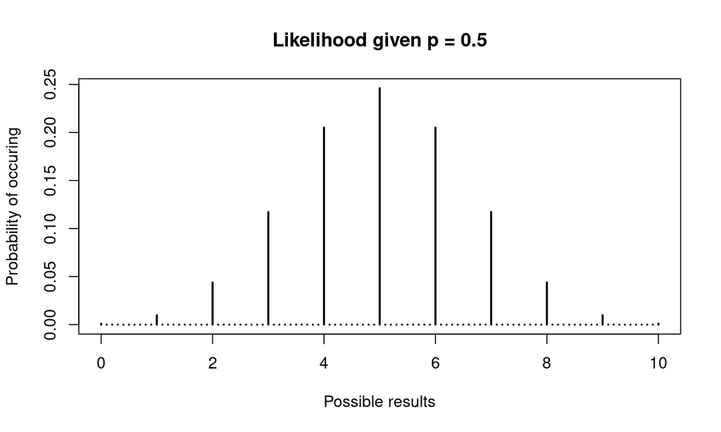

## Binomial likelihood

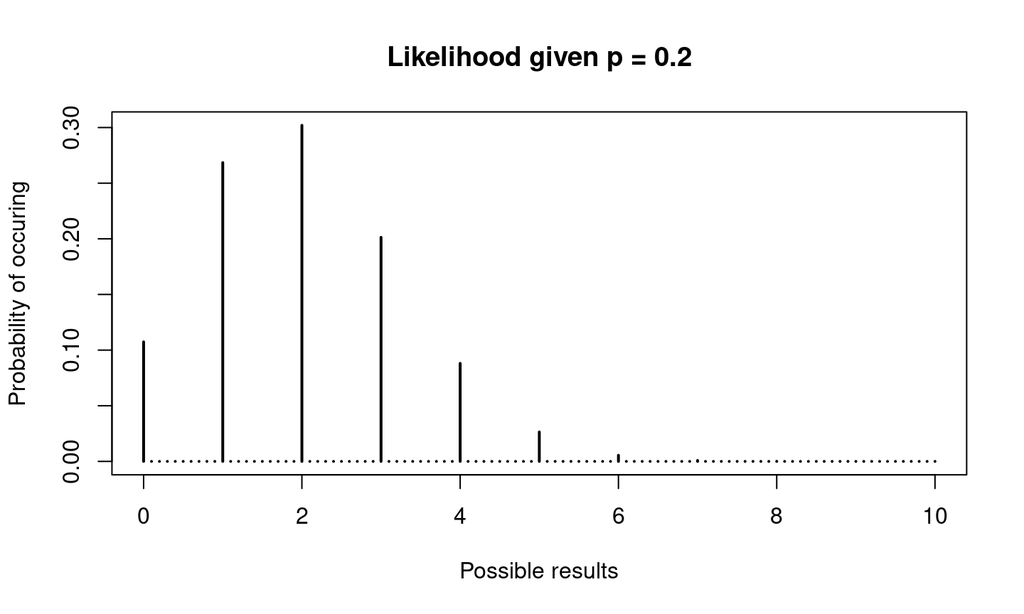

## Binomial likelihood

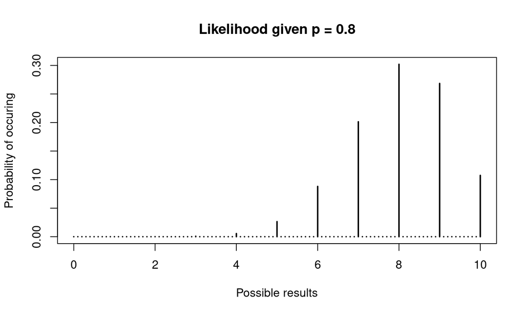

## Binomial likelihood

\(L(p | S,F) \propto p^S \times (1-p)^F, 0 < p < 1\)

- p - probability (parameter)
- S - number of successes or positive observations (data)
- F - number of failures or negative observations (data)

## Working with beta distribution

- Assigning degree of beliefs to parameter values can be very tedious, and with continuous parameters almost impossible
- We usually describe uncertainty associated with parameters by using some existing well known distribution
- When working with parameters reflecting proportion (i.e. taking values from 0 to 1), we usually use **beta distribution**

## Working with beta distribution

\(\pi(p) \propto p^{a-1} \times (1-p)^{b-1}, 0 < p < 1\)

- p - probability (parameter)
- a and b - hyperparameters reflecting the users prior beliefs about p
- mean of beta distribution is m = a/(a + b)
- variance of beta distribution is v = m(1-m)/(a+b+1)

## Working with beta distribution

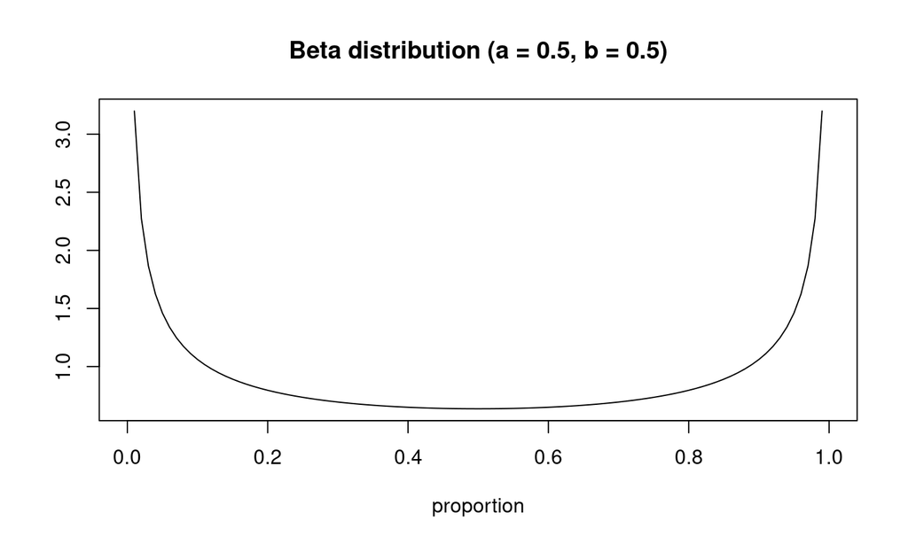

## Working with beta distribution

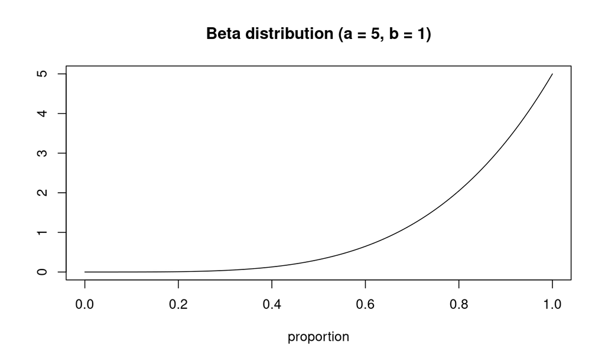

## Working with beta distribution

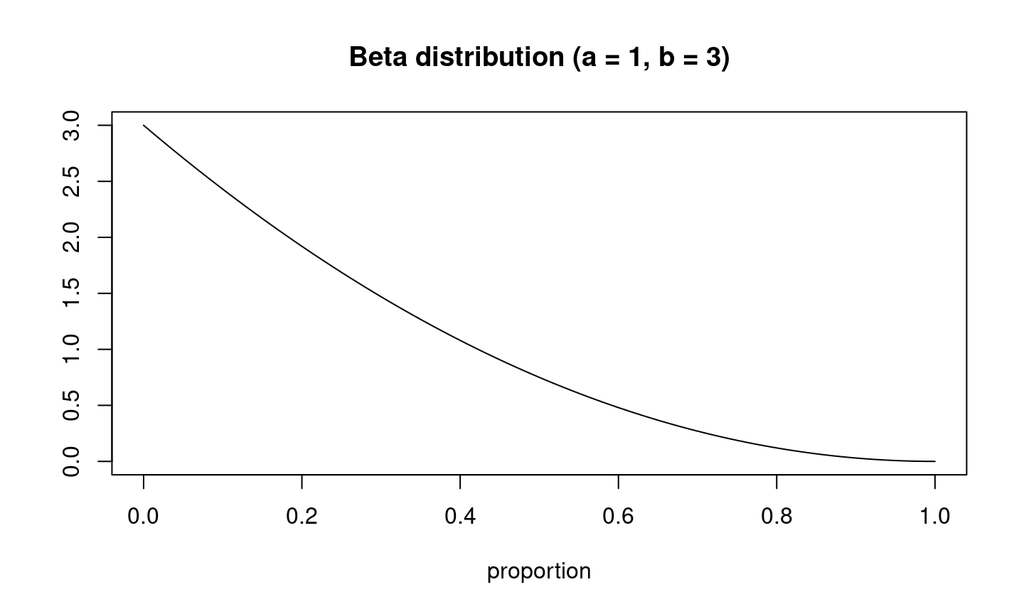

## Working with beta distribution

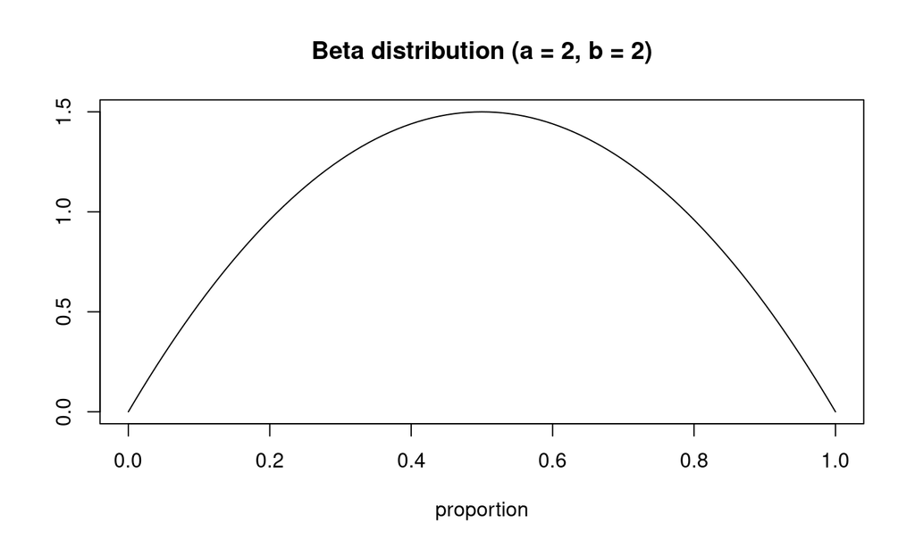

## Working with beta distribution

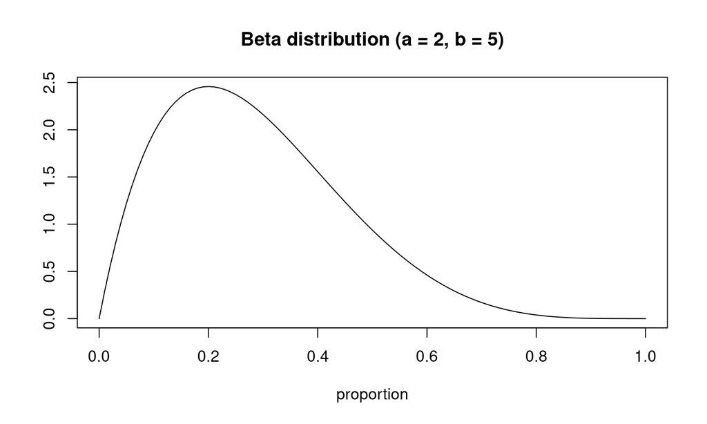

## Beta-binomial model

- Note how similar are formulas for binomial and beta distributions (up to a constant)

Binomial likelihood

\(L(p | S, F) \propto p^S \times (1-p)^F, 0 < p < 1\)

Beta prior

\(\pi(p) \propto p^{a-1} \times (1-p)^{b-1}, 0 < p < 1\)

## Beta-binomial model

- Note how similar are formulas for binomial and beta distributions (up to a constant)

Binomial likelihood

\(L(p | S,F) \propto p^S \times (1-p)^F, 0 < p < 1\)

Beta prior

\(\pi(p) \propto p^{a-1} \times (1-p)^{b-1}, 0 < p < 1\)

Beta posterior

\(L(p) \times \pi(p) = p^{(a+S)-1} \times (1-p)^{(b+F)-1}\)

## Beta binomial model

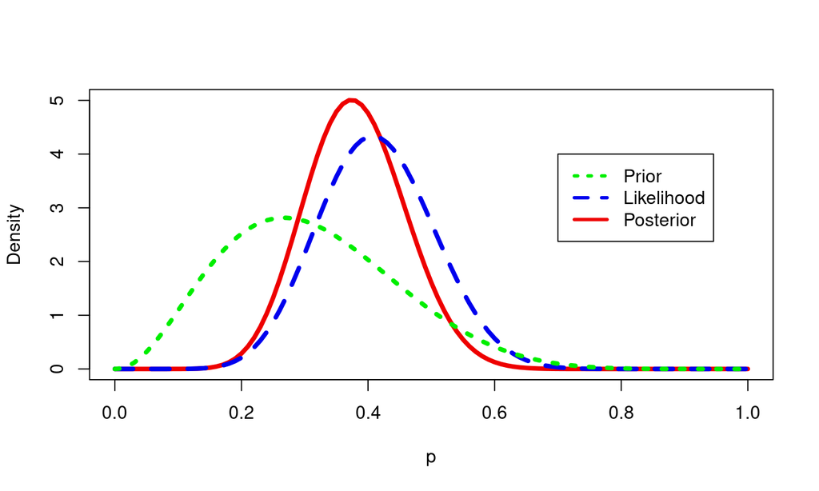